# Modelos de Negócio e Proposta de Valor para Empreendimentos Tecnológicos

Empreendedorismo Tecnológico e Desenvolvimento Territorial · Aula 09

Prof. Dr. Luiz Diego Vidal Santos

## Unidade II Visão Geral da Aula

Roteiro da aula · 4 horas Tópicos estruturantes

1. Conceito de Modelo de Negócio (Chesbrough & Rosenbloom; Teece, 2010).
2. *Business Model Canvas* (Osterwalder & Pigneur, 2010).
3. Proposta de Valor e ajuste produto–mercado (*Value Proposition Canvas*).
4. *Lean Startup*, MVP e *Customer Development* (Blank; Ries).
5. Adaptações para negócios de impacto e base tecnológica territorial.

Objetivo central Arquitetura de valor

Estruturar a lógica de **criação, entrega e captura de valor** em empreendimentos tecnológicos e de impacto, articulando o *Business Model Canvas* aos métodos ágeis de validação de hipóteses no território.

**Desdobramento prático:** articulada à oficina complementar 09a · Pitch Canvas.

# Arquitetura do Modelo de Negócio

## Conceito Tecnologia não gera valor sozinha (Chesbrough & Rosenbloom, 2002)

Teece, 2010 O papel mediador do modelo de negócio

- Uma mesma tecnologia gera resultados distintos conforme o **modelo de negócio** (venda de equipamento vs. *Software as a Service* — SaaS vs. licenciamento de PI).
- **Três funções centrais:**
  1. **Criar valor** para segmentos de clientes definidos;
  2. **Entregar valor** via canais, parceiros e operações;
  3. **Capturar valor** convertendo benefícios em receitas sustentáveis.

Arquétipos tecnológicos Padrões de captura de valor

- **Plataformas multilaterais:** conectam produtores locais e compradores (ex.: *marketplaces* agrícolas).
- *Freemium* / Assinatura (SaaS): receita recorrente e baixo custo marginal.
- **Isca e anzol (*Razor and Blade*):** equipamento subsidiado + insumo ou serviço recorrente.
- **Licenciamento de PI:** captura de *royalties* sem imobilizar capital em fábrica.

Inovação tecnológica sem desenho consistente de modelo de negócio permanece presa ao laboratório como invenção sem adoção.

# Canvas e Proposta de Valor

## Método Os 9 Blocos do Canvas e o Ajuste ao Cliente

| Lado da Eficiência | Centro | Lado do Valor |
| --- | --- | --- |
| Parcerias-Chave | **Proposta de Valor** | Relacionamento |
| Atividades-Chave |  | Canais |
| Recursos-Chave |  | Segmentos de Clientes |
| **Estrutura de Custos** |  | **Fontes de Receita** |

**Canvas Social / B:** para negócios de impacto territorial, acrescentam-se **Impacto Socioambiental Gerado** e distinção entre **Beneficiários vs. Pagadores**.

Value Proposition Canvas Encaixe produto–mercado (*Fit*)

- **Perfil do Cliente:** Tarefas (*Jobs*), Dores (*Pains*) e Ganhos (*Gains*).
- **Mapa de Valor:** Produtos/Serviços, Analgésicos (*Pain Relievers*) e Criadores de Ganho (*Gain Creators*).
- **Encaixe (*Fit*):** ocorre quando os atributos técnicos da solução resolvem dores reais e mensuráveis no território.

## Síntese Esquema: Business Model Canvas e Ciclo Lean

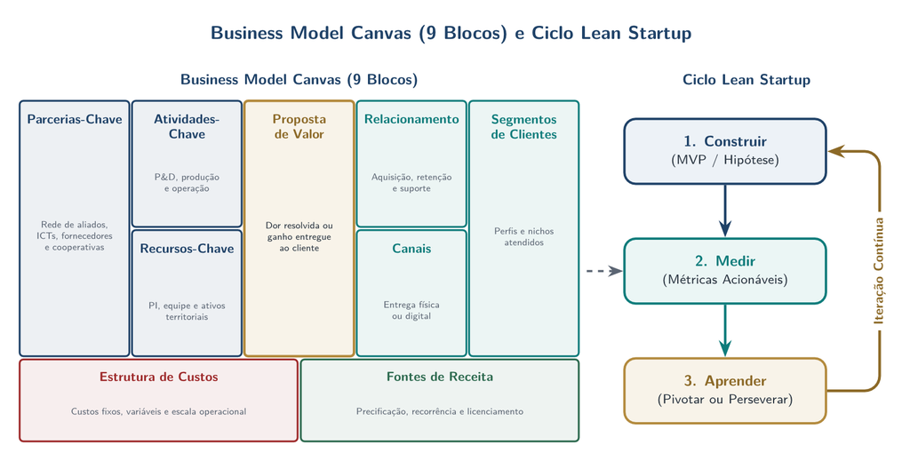

Os 9 blocos do Business Model Canvas (Osterwalder & Pigneur) integrados ao ciclo iterativo Construir–Medir–Aprender (Lean Startup).

Arquitetura dos 9 blocos integrada ao ciclo Construir–Medir–Aprender Eficiência interna, proposta de valor e mercado testados continuamente em campo

O Canvas organiza as hipóteses iniciais do negócio; o ciclo *Lean Startup* submete cada bloco ao teste empírico com usuários reais.

# Validação Enxuta (Lean Startup)

## Território Customer Development e Ciclo Construir–Medir–Aprender

Blank, 2013 · Ries Princípios da validação enxuta

- *“Nenhum plano de negócios sobrevive ao primeiro contato com o cliente”* (Blank, 2013).
- **Sair do prédio (*Get Out of the Building*):** testar hipóteses críticas antes de construir a solução definitiva.
- **MVP (Produto Mínimo Viável):** menor versão do produto que permite percorrer o ciclo **Construir $\rightarrow$ Medir $\rightarrow$ Aprender** com mínimo esforço.

Critério de decisão Pivotar ou perseverar?

- **Aprendizado validado:** métricas acionáveis (taxa de conversão, retenção, disposição a pagar) em vez de “métricas de vaidade” (curtidas, visitas).
- **Cuidado em *Deep Tech*:** quando a tecnologia exige validação laboratorial ou regulatória prévia, o MVP começa pela **validação do problema e da disposição a pagar** com clientes-piloto.

No contexto territorial, *sair do prédio* significa dialogar com associações, gestores públicos, produtores e compradores antes da imobilização de capital.

# Oficina e Leituras

## Método Oficina de Canvas + Plano de Validação (45 min)

**01 · Quadro inicial:** preencha os 9 blocos do **Canvas** para o seu empreendimento territorial distinguindo fatos de suposições.

**02 · Hipótese mais arriscada:** identifique qual premissa, se falhar, invalida toda a lógica de valor ou de receita.

**03 · MVP em 15 dias e métrica:** defina um teste de baixo custo no território e o critério objetivo que confirmará ou refutará a hipótese.

Preparação · Aula 10 Leituras para a próxima aula

- **DORNELAS, J. C. A.** *Empreendedorismo: transformando ideias em negócios* (Caps. sobre Plano de Negócios).
- **BYERS, T.; DORF, R.; NELSON, A.** *Technology ventures* (Caps. 18 e 19: Fontes de Financiamento).
- Editais vigentes de subvenção econômica (**FINEP / FAPESB**).